# STAT 140

SPRING 2020

## Fitting a line, residuals, and correlation

## MODELING NUMERICAL VARIABLES

In these notes, we will focus on quantifying the relationship between a

- **numerical response variable** and
- a **numerical explanatory variable**

## POVERTY VERSUS HIGH SCHOOL GRADUATE RATE

- **Response variable:**
- **Explanatory variable:**
- **Relationship:**

## POVERTY VERSUS HIGH SCHOOL GRADUATE RATE

- **Response variable:** percent in poverty
- **Explanatory variable:** percent high school grad
- **Relationship:** linear, negative, moderately strong

## POVERTY VERSUS HIGH SCHOOL GRADUATE RATE

The linear model for predicting poverty from high school graduation rate in the US is \[\widehat{poverty}=64.594-0.591\times hs\_grad\] The “hat” is used to signify this is an estimate.

The high school graduate rate in Hampshire County, MA is 92.4%. What poverty level does the model predict for this county?

## WHICH LINE IS IT ANYWAY?

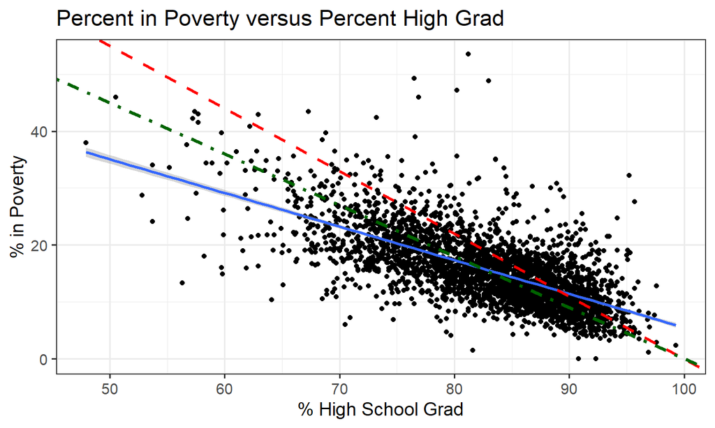

## RESIDUALS

Residuals are the leftovers from the model fit:

\[Data = Fit + Residual\]

Residual is the difference between the observed (\(y_i\)) and predicted \(\hat{y}_i\).

\[\underbrace{\hat{e}_i}_{residual}=\underbrace{y_i}_{data}-\underbrace{\hat{y}_i}_{fit}\]

- Hampshire County, MA: residual

1.691

## QUANTIFYING THE RELATIONSHIP

- **Correlation** describes the strength of the linear association between two variables.
- It takes values between -1 (perfect negative) and +1 (perfect positive).
- A value of 0 indicates no linear association.

## GUESSING THE CORRELATION

1. 0.70
2. -1.40
3. -0.68
4. 0.02
5. -0.30

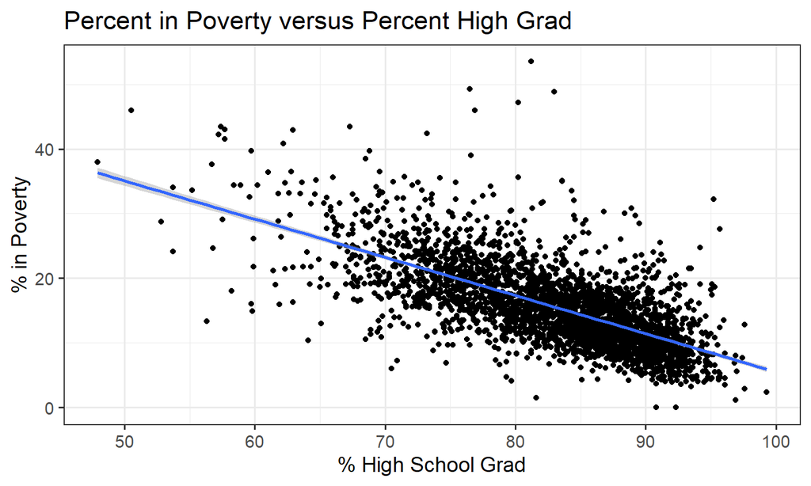

## GUESSING THE CORRELATION

1. 0.70
2. -1.40
3. **-0.68**
4. 0.02
5. -0.30

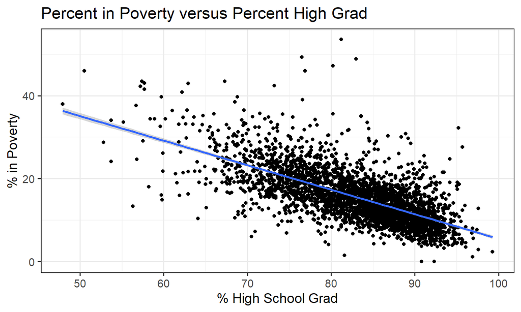

## ASSESSING THE CORRELATION

Which of the following is has the strongest correlation, i.e. correlation coefficient closest to +1 or -1?

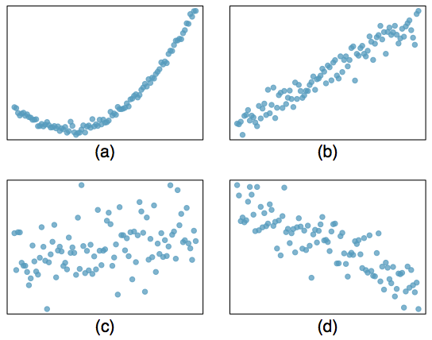

## ASSESSING THE CORRELATION

Which of the following is has the strongest correlation, i.e. correlation coefficient closest to +1 or -1? **(b) correlation - linear association**

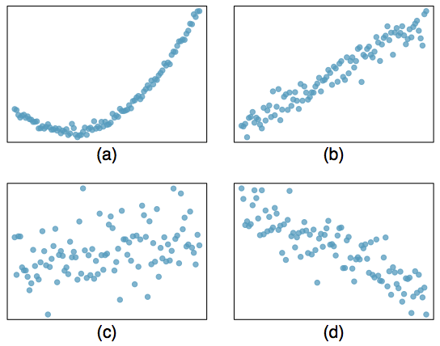

## Least squares regression

## WHICH LINE IS THE BEST LINE?

We want a line that has small residuals

1. Option 1: Minimize the sum of magnitudes (absolute values) of residuals \[|e_1| + |e_2| + … + |e_n|\]
2. Option 2: Minimize the sum of squared residuals – least squares \[e_1^2 + e_2^2 + … + e_n^2\]

## WHY LEAST SQUARES?

1. Most commonly used
2. Easier to compute by hand and using software
3. In many applications, a residual twice as large as another is usually more than twice as bad

## THE LEAST SQUARES LINE

\[\underbrace{\hat{y}}_{predicted \ y}=\underbrace{\hat{\beta}_0}_{est. \ intercept}+\underbrace{\hat{\beta_1}}_{est. \ slope}\underbrace{x}_{explanatory \ variable}\] Intercept:

- Parameter: \(\beta_0\)
- Point estimate: \(\hat{\beta}_0\)

Slope:

- Parameter: \(\beta_1\)
- Point estimate: \(\hat{\beta}_1\)

## CONDITIONS FOR THE LEAST SQUARES LINE

1. Linearity
2. Nearly normal residuals
3. Constant variability

## CONDITIONS: (1) LINEARITY

- The relationship between the response and explanatory variable should be **linear** .
- Methods to fit nonlinear relationships exist - see advanced statistics classes for this.
- To assess whether this condition is met, check the *residual plot*:

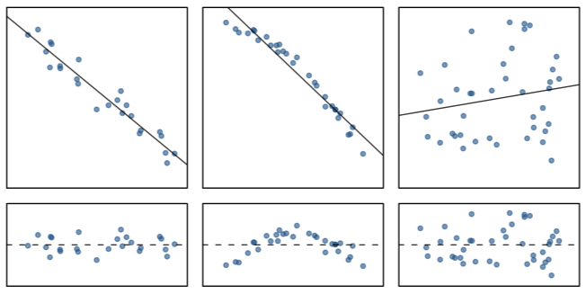

## CONDITIONS: (2) NEARLY NORMAL RESIDUALS

- The residuals should be nearly normal.
- This condition may not be satisfied when there are unusual observations that don’t follow the trend of the rest of the data.
- To assess whether this condition is met, check *using a histogram or normal probability (qq)plot of residuals*.

## CONDITIONS: (3) CONSTANT VARIABILITY

- The variability of points around the least squares line should be roughly constant.
- This implies that the variability of residuals around the 0 line should be roughly constant as well.
- Also called *homoscedasticity*.
- To assess whether this condition is met, check *using a residual plot*.

## SLOPE

The slope of the regression line can be calculated as

\[\hat{\beta}_1=\frac{s_y}{s_x}R\] where \(s_y\) and \(s_x\) are the standard deviations associated with \(y\) and \(x\) and \(R\) is the correlation.

## INTERCEPT

The intercept is where the regression line intersects the y-axis. The calculation of the intercept uses the fact the a regression line always passes through (\(\bar{x}\), \(\bar{y}\)).

\[\hat{\beta}_0=\bar{y}-\hat{\beta}_1\bar{x}\]

## INTERPRETATION OF SLOPE AND INTERCEPT

- *Intercept:* When x = 0, y is expected to equal the intercept.
- *Slope:* For each unit in x, y is expected to increase/decrease on average by the slope.

*These statements are not causal unless the study is a randomized controlled experiment.*

## PREDICTION

- Using the linear model to predict the value of the response variable for a given value of the explanatory variable is called **prediction**, simply by plugging in the value of x in the linear model equation.
- There will be some uncertainty associated with the predicted value.

## EXTRAPOLATION

- Applying a model estimate to values outside of the realm of the original data is called **extrapolation**.
- Sometimes the intercept might be an extrapolation.

## \(R^2\)

- The strength of the fit of a **linear** model is most commonly evaluated using \(R^2\).
- \(R^2\) is calculated as the square of the correlation coefficient.
- It tells us what percent of variability in the response variable is explained by the model.
- The remainder of the variability is explained by variables not included in the model or by inherent randomness in the data.

## REFERENCES

- Diez et al. (2019) OpenIntro Statistics, Fourth Edition